# Evolucion del nivel de estudios alcanzado por la poblacion española

Serie de tiempo

Marco Javier Peñaloza Pérez

2023-04-25

# **Introducción**

La evolución de la educación en España desde la década de 1960 ha sido un proceso significativo en la historia del país. Durante este período, la educación en España ha experimentado una serie de cambios importantes que han transformado radicalmente el sistema educativo y la forma en que se imparte la enseñanza, en el siguiente trabajo se realiza una exploración de una base de datos recogida con los porcentajes de habitantes que han alcanzado un nivel máximo de educación y cómo a través del tiempo se ha visto una mejora importante mejorando los índice de educación.

# **1. Problema de Investigación**

## **1.1. Definición del problema**

La formación académica de las personas es una variable muy importante en la evolución de la sociedad, al pasar los años las diferentes naciones han implementado mecanismos que buscan que los habitantes de un país mejores sus niveles de educación. Tal es el caso de la población española, de la cual, se tiene una base de datos con los porcentaje de personas que pertenecen a un determinado nivel académico y que se ha visto evolucionado a medida que transcurre el tiempo, por tanto, se hace interesante hacer una exploración y análisis de la serie temporal para sacar conclusiones sobre el progreso y hacer estimaciones a futuro.

## **1.2. Justificación**

La propuesta de análisis de series de tiempo en educación en la población española es importante debido a que permite obtener información valiosa sobre la evolución de los niveles académicos mediante el análisis temporal y hacer pronósticos sobre lo que se puede esperar del fenómeno en si.

## **1.3. Objetivo**

Conocer la evolución temporal de los niveles de educación de España entre los años 1960 a 2020.

# **2. Metodología**

## **2.1 Recopilación de datos**

Se recolectó información sobre el nivel educativo de la población en España, los cuales han sido tomados de la página: https://www.epdata.es/datos/educacion-espana-mundo-datos-graficos/274

## **2.2 Análisis exploratorio de datos:**

### **2.2.1 Carga de la base de datos**

```r
library(readxl)
data1 <- read_excel("C:/Users/mjpenalozap/Desktop/estudios en españa.xlsx")
head(data, n=6)
```

[output not shown]

La base de datos nos da información sobre la fecha en que fueron recogidos los informes sobre los porcentajes de habitantes en españa que pertenecen a los niveles de educación primaria, secundaria y universitario.

### **2.2.2. Resumen estadístico de los datos**

```
##      fecha                       Primarios     Primer ciclo de Secundaria
##  Min.   :1960-01-01 00:00:00   Min.   :22.00   Min.   : 1.76
##  1st Qu.:1974-10-01 18:00:00   1st Qu.:37.10   1st Qu.: 5.17
##  Median :1989-07-02 12:00:00   Median :62.79   Median :13.25
##  Mean   :1989-07-02 06:00:00   Mean   :56.70   Mean   :13.87
##  3rd Qu.:2004-04-01 12:00:00   3rd Qu.:75.66   3rd Qu.:22.96
##  Max.   :2019-01-01 00:00:00   Max.   :78.58   Max.   :25.65
##  Segundo ciclo de Secundaria Primer ciclo de educación superior
##  Min.   : 1.760              Min.   : 1.540
##  1st Qu.: 2.995              1st Qu.: 2.990
##  Median :10.640              Median : 4.230
##  Mean   :11.448              Mean   : 5.224
##  3rd Qu.:19.290              3rd Qu.: 7.348
##  Max.   :24.760              Max.   :11.300
##  Segundo ciclo de educación superior
##  Min.   : 1.360
##  1st Qu.: 2.120
##  Median : 4.070
##  Mean   : 5.958
##  3rd Qu.: 9.182
##  Max.   :15.640
```

Se puede observar que lo datos han sido recogidos entre los años 1960 y 2019, existen 5 niveles de educación entre los que se encuentran: Primaria Primer ciclo de secundaria Segundo ciclo de secundaria Primer ciclo de educación superior Segundo ciclo de educación superior

En cada nivel se observa un resumen de 5 puntos con los valores mínimo, máximo y los tres cuartiles.

### **2.2.3. Histogramas de las variables**

[figure not shown]

### **2.2.4 Creación del objeto ts**

Se realiza una modificación de la base de datos. Entre los cambios están:

Cambiar la variable temporal al formato de fecha. Consolidar la variable de interés, que en este análisis se ha seleccionado Primaria. Construir el objeto ts.

```
##        Jan   Feb   Mar   Apr   May   Jun   Jul   Aug   Sep   Oct   Nov   Dec
## 2018 78.55 78.55 78.56 78.56 78.56 78.56 78.57 78.57 78.57 78.57 78.58 77.96
## 2019 77.35 76.73 76.12 75.50 74.89 74.27 73.66 73.04 72.43 71.81 70.75 69.69
## 2020 68.63 67.57 66.51 65.45 64.38 63.32 62.26 61.20 59.08 56.96 54.83 52.71
## 2021 50.59 48.47 46.34 44.22 42.10 39.97 39.09 38.21 37.32 36.44 35.56 34.68
## 2022 33.79 32.91 32.03 31.14 30.00 28.86 27.72 26.57 25.43 24.29 23.15 22.00
```

Ahora se realiza una gráfica del objeto ts:

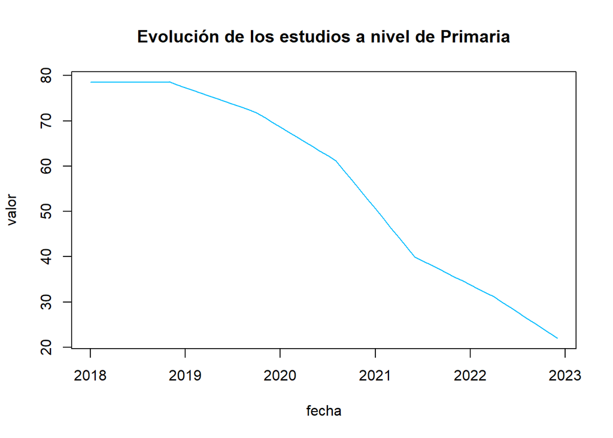

```r
plot(indice.ts, main = "",ylab="valor",col="deepskyblue",xlab="fecha")
title(main = "Evolución de los estudios a nivel de Primaria")
```

**Análisis de la gráfica**

Se puede observar que a medida que han pasado los años el porcentaje de personas que sólo tenían nivel de primaria ha disminuido en España, esto quiere decir que el nivel académico fue mejorando con el tiempo.

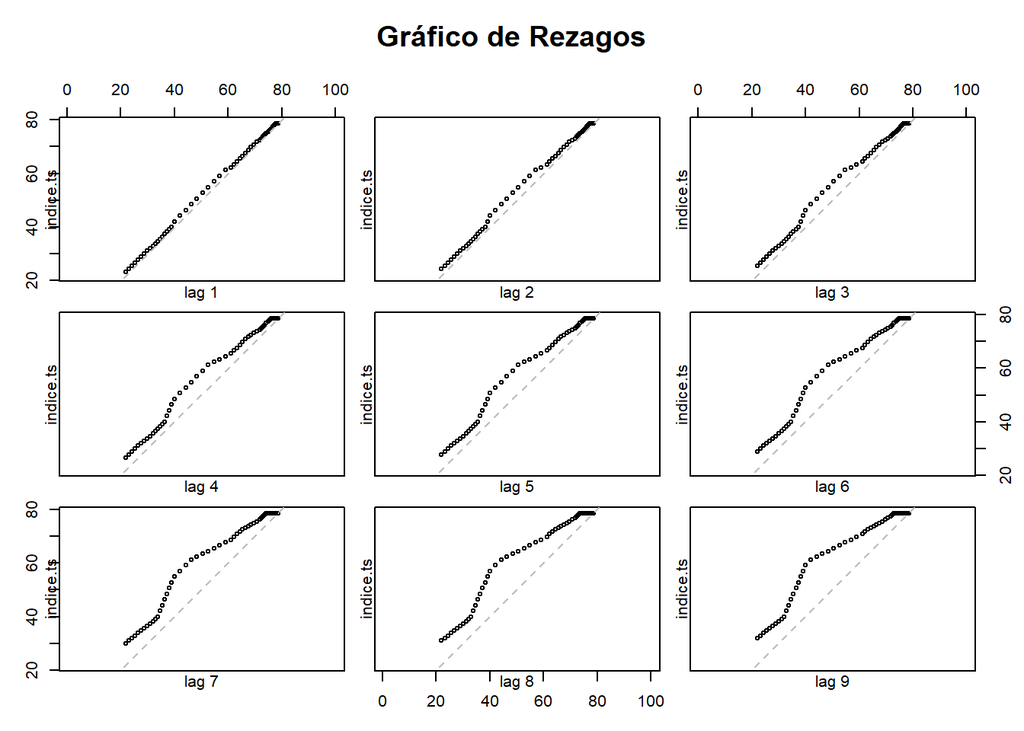

### **2.2.5. Media Móvil**

Se procede a crear 3 medias móviles:

```r
library(zoo)
mediamovil1 <- rollmean(indice.ts,k=3)
cat("Media Movil con 3 meses: ", mediamovil1,"\n\n")
```

```
## Media Movil con 3 meses:  78.55333 78.55667 78.56 78.56 78.56333 78.56667 78.57 78.57 78.57333 78.37 77.96333 77.34667 76.73333 76.11667 75.50333 74.88667 74.27333 73.65667 73.04333 72.42667 71.66333 70.75 69.69 68.63 67.57 66.51 65.44667 64.38333 63.32 62.26 60.84667 59.08 56.95667 54.83333 52.7…
```

```r
mediamovil2 <- rollmean(indice.ts,k=4)
cat("Media Movil con 4 meses: ", mediamovil2,"\n\n")
```

```
## Media Movil con 4 meses:  78.555 78.5575 78.56 78.5625 78.565 78.5675 78.57 78.5725 78.42 78.115 77.655 77.04 76.425 75.81 75.195 74.58 73.965 73.35 72.735 72.0075 71.17 70.22 69.16 68.1 67.04 65.9775 64.915 63.8525 62.79 61.465 59.875 58.0175 55.895 53.7725 51.65 49.5275 47.405 45.2825 43.1575 4…
```

```r
mediamovil3 <- rollmean(indice.ts,k=6)
cat("Media Movil con 6 meses: ", mediamovil3)
```

```
## Media Movil con 6 meses:  78.55667 78.56 78.56333 78.565 78.56667 78.57 78.47 78.26667 77.96 77.55167 77.04 76.425 75.81 75.195 74.58 73.965 73.35 72.66 71.89667 71.05833 70.14667 69.16 68.1 67.03833 65.97667 64.915 63.85333 62.615 61.2 59.60833 57.84 55.895 53.77333 51.65 49.52667 47.405 45.2816…
```

**Comparación de las medias con los datos originales de la base**

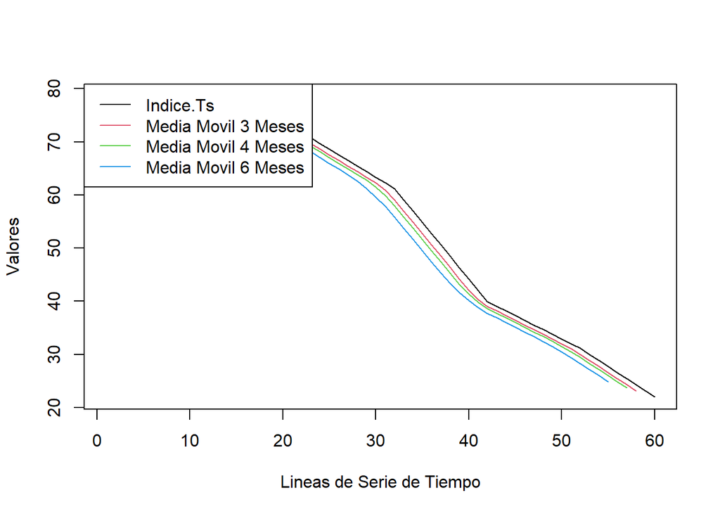

# **3 Estacionalidad y Descomposición:**

## **3.1 Estacionalidad**

```r
library(ggseas)
library(forecast)
```

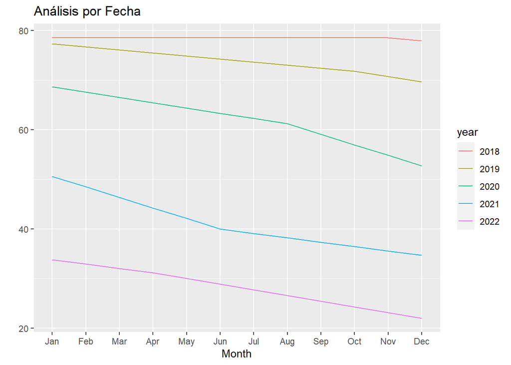

```r
ggseasonplot(x = indice.ts,
             main= "Análisis por Fecha")
```

Se observa que en todos los años hay una disminución de los porcentajes en cada nivel académico de primaria.

## **3.2. Descomposición del objeto y análisis**

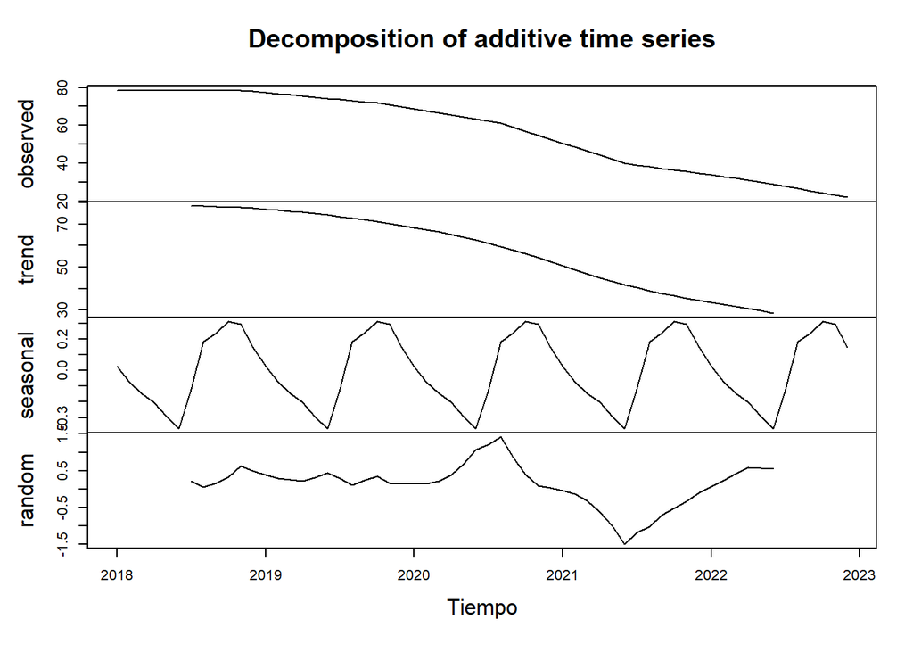

## **3.3 Prueba de Estacionalidad**

```
##
##  Augmented Dickey-Fuller Test
##
## data:  indice.ts
## Dickey-Fuller = -2.7277, Lag order = 3, p-value = 0.2807
## alternative hypothesis: stationary
```

## **3.4. Autocorrelación**

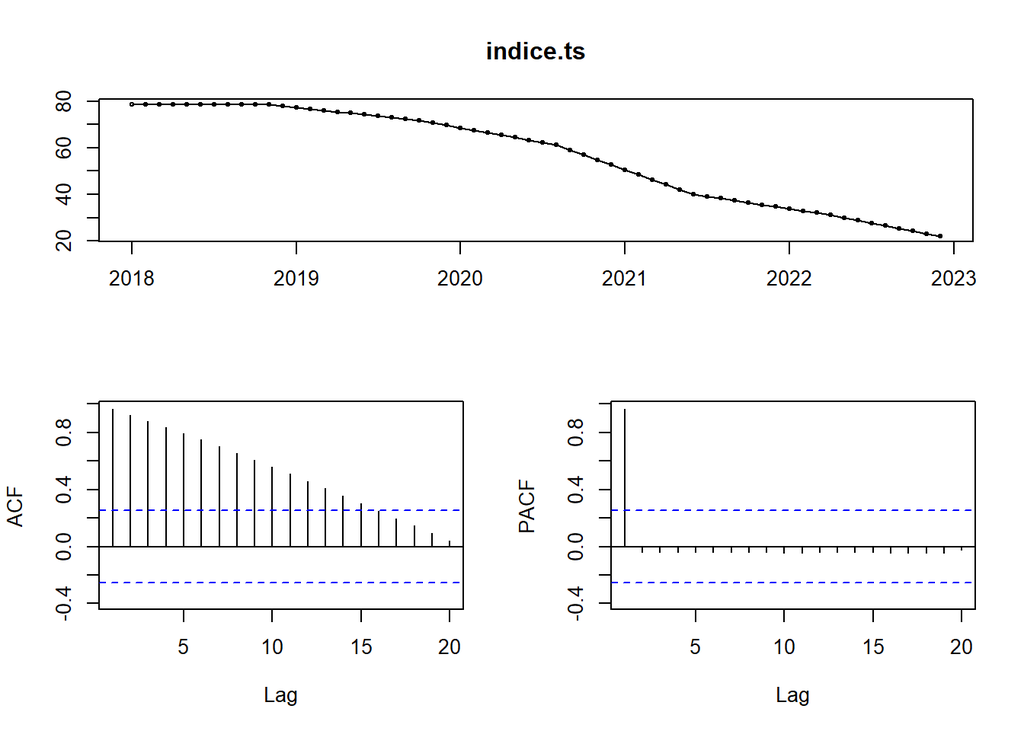

## **3.5 Transformación**

Se ajusta la estacionalidad de la serie temporal.

```r
indice_adj <- seasadj(descomposicion)
```

Se remueve la tedencia (trend) para el modelo.

```r
modelo_ts <- diff(indice_adj)
```

Se grafica la nueva descomposición.

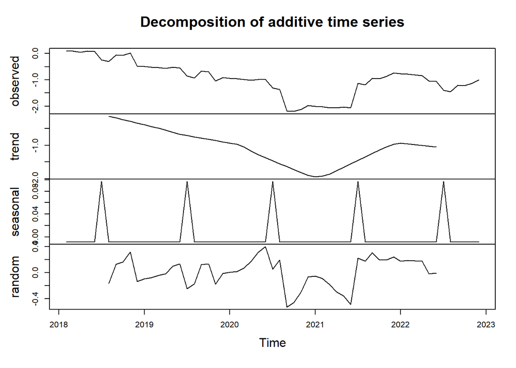

## **3.6 Validación de la nueva serie de tiempo transformada**

**Test de estacionalidad**

```
##
##  Augmented Dickey-Fuller Test
##
## data:  modelo_ts
## Dickey-Fuller = -1.5762, Lag order = 3, p-value = 0.7459
## alternative hypothesis: stationary
```

**Test de autocorrelación**

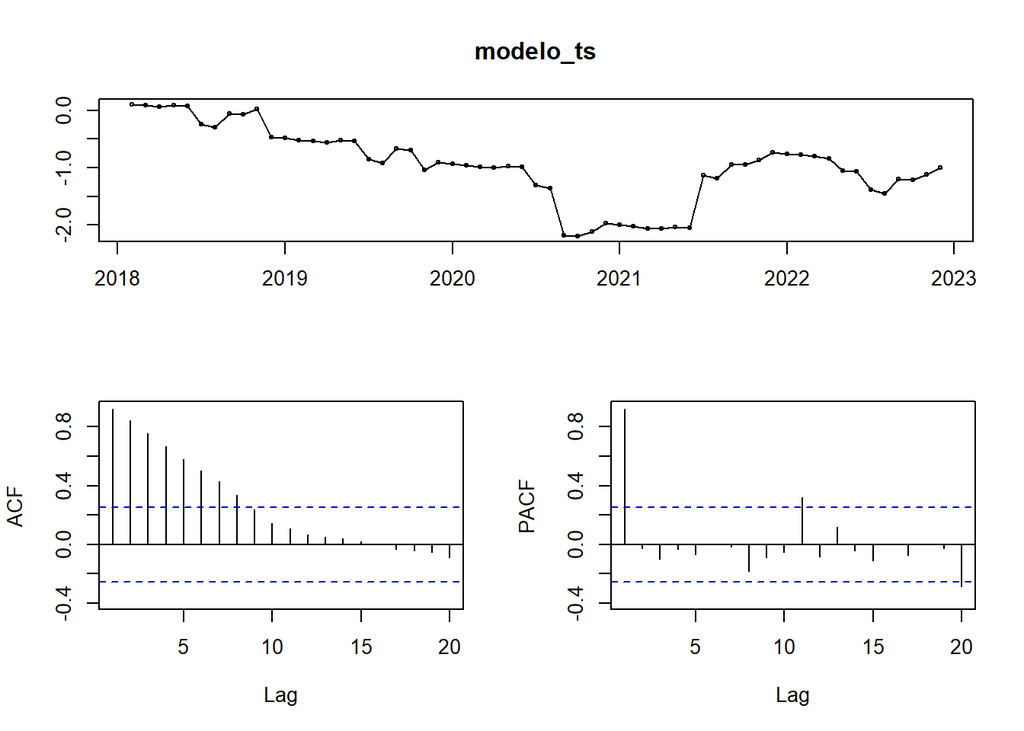

# **4. Holt-Winters(HW) y Suavizamiento Exponencial**

## **4.1 Holt-Winters(HW)**

Holt-Winters es un método ampliamente utilizado en el análisis de series de tiempo para realizar pronósticos a corto plazo. Esto permite predecir cambios en la tendencia a lo largo del tiempo, lo cual es especialmente útil cuando se trabaja con datos que presentan una tendencia ascendente o descendente.

```r
hw_model <- HoltWinters(indice.ts)

# Componentes del modelo (tendencia, estacionalidad y residuos)
trend <- hw_model$components$trend
seasonal <- hw_model$components$seasonal
residuals <- hw_model$components$random

# Imprimir las componentes
print("Tendencia:")
```

```
## [1] "Tendencia:"
```

```r
print(trend)
```

[output not shown]

```r
print("Estacionalidad:")
```

```
## [1] "Estacionalidad:"
```

```r
print(seasonal)
```

[output not shown]

```r
print("Residuos:")
```

```
## [1] "Residuos:"
```

```r
print(residuals)
```

[output not shown]

## **4.2 Suavizamiento Exponencial**

Holt-Winters utiliza técnicas de suavizado exponencial para predecir los valores futuros de una serie de tiempo. Esto implica asignar pesos exponenciales a los puntos de datos históricos, lo que da mayor importancia a los datos más recientes. Esta característica es útil para adaptarse a los cambios en los patrones de la serie de tiempo a medida que los datos más recientes tienen un impacto más significativo en las predicciones.

A continuación, se aplica el suavizamiento exponencial

```r
smoothed <- HoltWinters(indice.ts, beta = FALSE, gamma = FALSE)$fitted

print("Serie de tiempo suavizada:")
```

```
## [1] "Serie de tiempo suavizada:"
```

```r
print(smoothed)
```

```
##              xhat    level
## Feb 2018 78.55000 78.55000
## Mar 2018 78.55000 78.55000
## Apr 2018 78.56000 78.56000
## May 2018 78.56000 78.56000
## Jun 2018 78.56000 78.56000
## Jul 2018 78.56000 78.56000
## Aug 2018 78.57000 78.57000
## Sep 2018 78.57000 78.57000
## Oct 2018 78.57000 78.57000
## Nov 2018 78.57000 78.57000
## Dec 2018 78.58000 78.58000
## Jan 2019 77.96003 77.96003
## Feb 2019 77.35003 77.35003
## Mar 2019 76.73003 76.73003
## Apr 2019 76.12003 76.12003
## May 2019 75.50003 75.50003
## Jun 2019 74.89003 74.89003
## Jul 2019 74.27003 74.27003
## Aug 2019 73.66003 73.66003
## Sep 2019 73.04003 73.04003
## Oct 2019 72.43003 72.43003
## Nov 2019 71.81003 71.81003
## Dec 2019 70.75005 70.75005
## Jan 2020 69.69005 69.69005
## Feb 2020 68.63005 68.63005
## Mar 2020 67.57005 67.57005
## Apr 2020 66.51005 66.51005
## May 2020 65.45005 65.45005
## Jun 2020 64.38005 64.38005
## Jul 2020 63.32005 63.32005
## Aug 2020 62.26005 62.26005
## Sep 2020 61.20005 61.20005
## Oct 2020 59.08011 59.08011
## Nov 2020 56.96011 56.96011
## Dec 2020 54.83011 54.83011
## Jan 2021 52.71011 52.71011
## Feb 2021 50.59011 50.59011
## Mar 2021 48.47011 48.47011
## Apr 2021 46.34011 46.34011
## May 2021 44.22011 44.22011
## Jun 2021 42.10011 42.10011
## Jul 2021 39.97011 39.97011
## Aug 2021 39.09004 39.09004
## Sep 2021 38.21004 38.21004
## Oct 2021 37.32005 37.32005
## Nov 2021 36.44004 36.44004
## Dec 2021 35.56004 35.56004
## Jan 2022 34.68004 34.68004
## Feb 2022 33.79005 33.79005
## Mar 2022 32.91004 32.91004
## Apr 2022 32.03004 32.03004
## May 2022 31.14005 31.14005
## Jun 2022 30.00006 30.00006
## Jul 2022 28.86006 28.86006
## Aug 2022 27.72006 27.72006
## Sep 2022 26.57006 26.57006
## Oct 2022 25.43006 25.43006
## Nov 2022 24.29006 24.29006
## Dec 2022 23.15006 23.15006
```

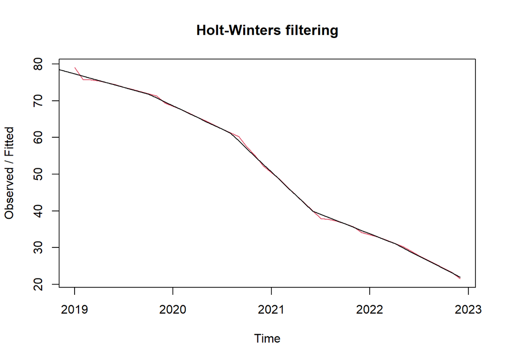

```r
hw_model=HoltWinters(indice.ts, seasonal = "additive")
plot(hw_model)
```

Se genera un gráfico en color rojo que representa una serie de datos aproximada a los datos originales en color negro.

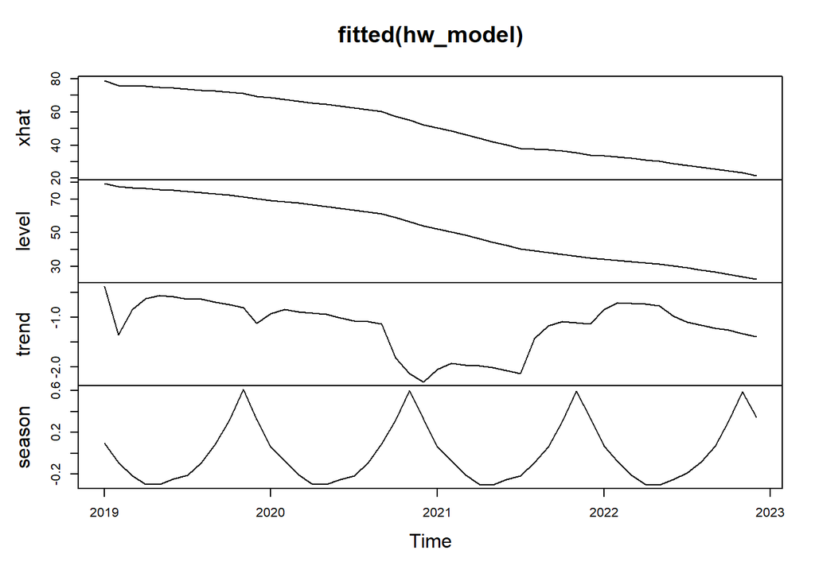

```r
plot(fitted(hw_model))
```

En el gráfico se observa la descomposición en las cuatro componentes. El método Holt Winters nos permite realizar predicciones utilizando la serie de tiempo. A continuación, se muestra el proceso de generación de predicciones.

```r
pred=predict(hw_model, 12, prediction.interval = TRUE)
pred
```

```
##                fit      upr        lwr
## Jan 2023 20.603545 21.45003 19.7570629
## Feb 2023 19.346334 20.91322 17.7794447
## Mar 2023 18.102824 20.49530 15.7103431
## Apr 2023 16.902669 20.21960 13.5857324
## May 2023 15.779169 20.11143 11.4469037
## Jun 2023 14.722029 20.15364  9.2904176
## Jul 2023 13.678689 20.28798  7.0693939
## Aug 2023 12.675394 20.53598  4.8148131
## Sep 2023 11.715027 20.89649  2.5335600
## Oct 2023 10.841649 21.41017  0.2731282
## Nov 2023 10.017926 22.03669 -2.0008400
## Dec 2023  8.676006 22.20559 -4.8535801
```

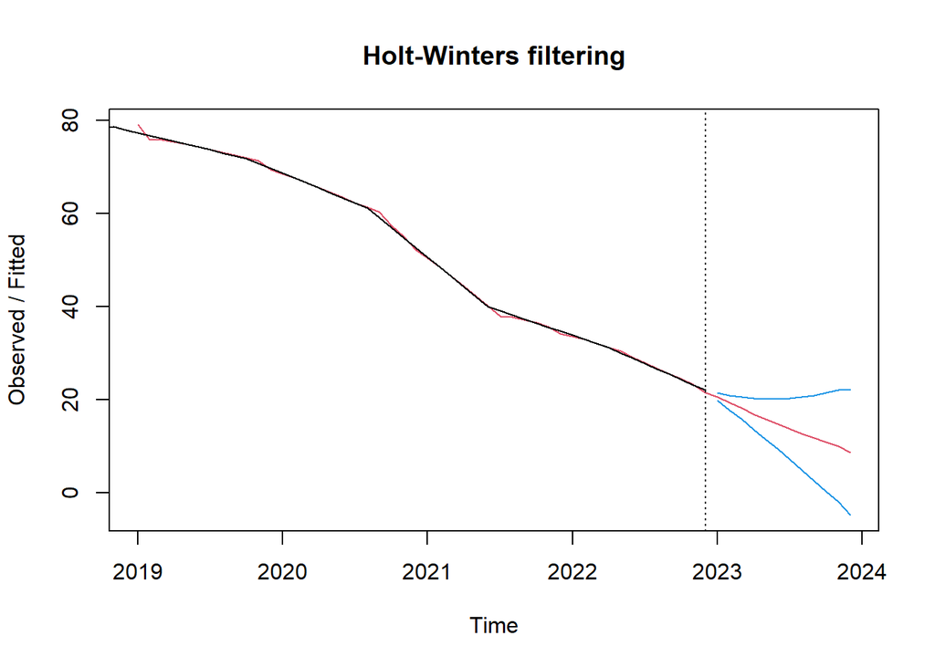

```r
plot(hw_model, pred)
```

Podemos observar la tendencia del pronóstico con sus respectivos intervalos de confianza.

```r
hw_model1 <- HoltWinters(indice.ts)
hw_model1
```

```
## Holt-Winters exponential smoothing with trend and additive seasonal component.
##
## Call:
## HoltWinters(x = indice.ts)
##
## Smoothing parameters:
##  alpha: 0.9795124
##  beta : 0.5902795
##  gamma: 1
##
## Coefficients:
##            [,1]
## a   21.64107487
## b   -1.11033287
## s1   0.07280293
## s2  -0.07407501
## s3  -0.20725266
## s4  -0.29707475
## s5  -0.31024149
## s6  -0.25704834
## s7  -0.19005534
## s8  -0.08301749
## s9   0.06694778
## s10  0.30390325
## s11  0.59051269
## s12  0.35892513
```

Predicciones para los próximos 12 periodos.

```r
library(forecast)
predictions <- forecast(hw_model1, h = 12)
```

[figure not shown]

```r
plot(hw_model1, main = "Modelo de Holt-Winters: Serie de tiempo y Predicciones")
lines(predictions$mean, col = "blue")
legend("bottomright", legend = c("Serie de tiempo", "Predicciones"), col = c("black", "blue"), lty = 1)
```

# **5. Modelo ARIMA**

Metodología Box-Jenkins para identificar modelos autoregresivos integrados de media móvil (ARIMA) para analizar y predecir valores futuros de serie de tiempo.

## **5.1 Modelos**

```
## [1] "Verificamos la estacionalidad del modelo (p<0.05)"
```

```
##
##  Augmented Dickey-Fuller Test
##
## data:  modelo_ts
## Dickey-Fuller = -1.5762, Lag order = 3, p-value = 0.7459
## alternative hypothesis: stationary
```

## **5.2 Modelo basado solamente en Auto Regresión (AR)**

Debemos ubicar los parámetros d y q en 0.

Por medio del análisis ACF y PACF verificamos los lags

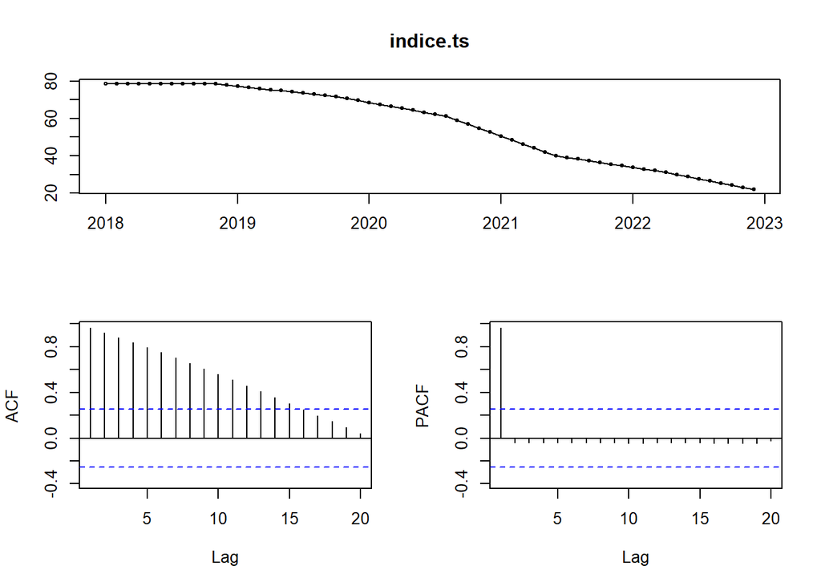

Procedemos a diferenciarla ya que es No-Estacionaria

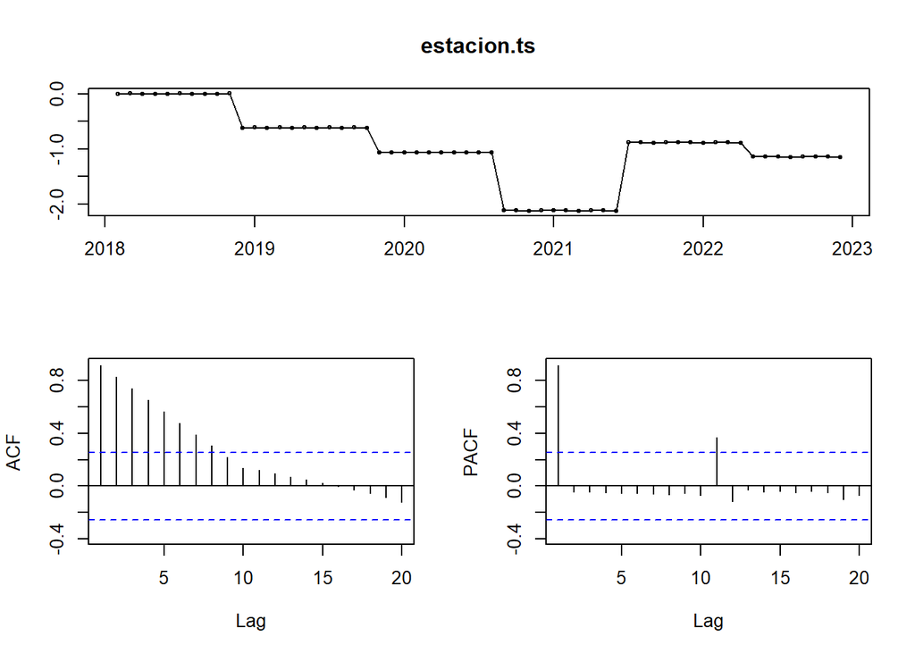

```
## [1] 1
```

En el gráfico PAFC podemos ver los lag en 1 como punto significativo de cambio.

Construyamos entonces nuestro modelo con valor AR (p) = 1. A tener en cuenta: Al tener un modelo diferenciado, se debe especificar que no se incluya la media en los cálculos ya que su valor es 0.

```
##
## Call:
## arima(x = estacion.ts, order = c(1, 0, 0), include.mean = F)
##
## Coefficients:
##          ar1
##       0.9734
## s.e.  0.0220
##
## sigma^2 estimated as 0.05666:  log likelihood = -0.51,  aic = 5.02
```

## **5.3 Modelo basado solamente en el Moving Average (MA).**

*Parámetros p y d en 0*

Utilizando el gráfico ACF se revisa cual sería el punto de inflexión y luego procedemos a crear el modelo

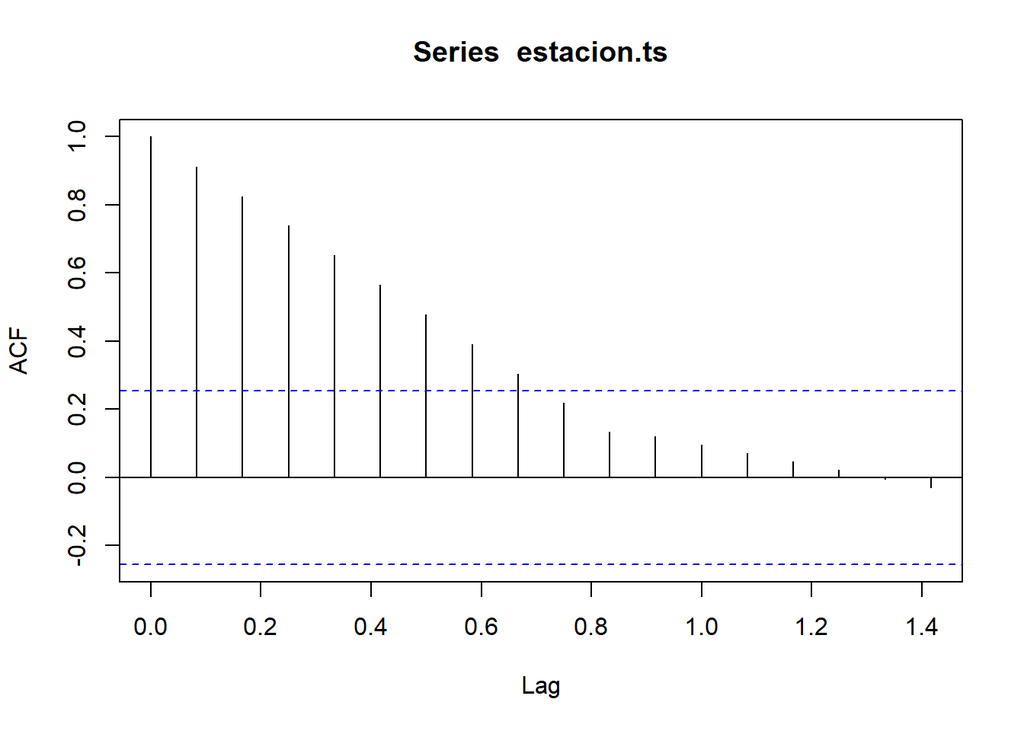

[output not shown]

```
##
## Call:
## arima(x = estacion.ts, order = c(0, 0, 2), include.mean = F)
##
## Coefficients:
##          ma1     ma2
##       1.3927  0.7687
## s.e.  0.1321  0.1169
##
## sigma^2 estimated as 0.2129:  log likelihood = -39.46,  aic = 84.93
```

## **5.4 Modelo ARIMA. Validación por medio de la función auto.arima**

Se sabe que la seleccion de parámetros del modelo clasico Arima, depende de las características de la serie de tiempo a evaluar. Por lo que se compara el cálculo manual de las variables con respecto al modelo automático que viene incluido en la librería de *forecast* auto.arima.

Para mostrar los resultados, se habilita la opción *trace* la cual permite evaluar todos los modelos que pudiesen resultar de la serie de tiempo. Así mismo, se utiliza dos parámetros más y configurarlos en Falso - Stepwise y Approximation - los cuales maximizan la búsqueda del mejor modelo, al tiempo que sacrifica tanto número de modelos a evaluar así como velocidad de respuesta.

```
##
##  ARIMA(0,1,0)                               : 1.145366
##  ARIMA(0,1,0)            with drift         : 2.895054
##  ARIMA(0,1,0)(0,0,1)[12]                    : 3.292119
##  ARIMA(0,1,0)(0,0,1)[12] with drift         : 5.120821
##  ARIMA(0,1,0)(1,0,0)[12]                    : 3.292119
##  ARIMA(0,1,0)(1,0,0)[12] with drift         : 5.12083
##  ARIMA(0,1,0)(1,0,1)[12]                    : Inf
##  ARIMA(0,1,0)(1,0,1)[12] with drift         : Inf
##  ARIMA(0,1,1)                               : 3.290099
##  ARIMA(0,1,1)            with drift         : 5.111568
##  ARIMA(0,1,1)(0,0,1)[12]                    : 5.51635
##  ARIMA(0,1,1)(0,0,1)[12] with drift         : 7.42161
##  ARIMA(0,1,1)(1,0,0)[12]                    : 5.51635
##  ARIMA(0,1,1)(1,0,0)[12] with drift         : 7.421614
##  ARIMA(0,1,1)(1,0,1)[12]                    : Inf
##  ARIMA(0,1,1)(1,0,1)[12] with drift         : Inf
##  ARIMA(0,1,2)                               : 5.516359
##  ARIMA(0,1,2)            with drift         : 7.419046
##  ARIMA(0,1,2)(0,0,1)[12]                    : 7.826614
##  ARIMA(0,1,2)(0,0,1)[12] with drift         : 9.816897
##  ARIMA(0,1,2)(1,0,0)[12]                    : 7.826614
##  ARIMA(0,1,2)(1,0,0)[12] with drift         : 9.816925
##  ARIMA(0,1,2)(1,0,1)[12]                    : Inf
##  ARIMA(0,1,2)(1,0,1)[12] with drift         : Inf
##  ARIMA(0,1,3)                               : 7.826626
##  ARIMA(0,1,3)            with drift         : 9.815291
##  ARIMA(0,1,3)(0,0,1)[12]                    : 10.22574
##  ARIMA(0,1,3)(0,0,1)[12] with drift         : 12.30719
##  ARIMA(0,1,3)(1,0,0)[12]                    : 10.22574
##  ARIMA(0,1,3)(1,0,0)[12] with drift         : 12.30721
##  ARIMA(0,1,3)(1,0,1)[12]                    : Inf
##  ARIMA(0,1,3)(1,0,1)[12] with drift         : Inf
##  ARIMA(0,1,4)                               : 10.22547
##  ARIMA(0,1,4)            with drift         : 12.30682
##  ARIMA(0,1,4)(0,0,1)[12]                    : 12.71866
##  ARIMA(0,1,4)(0,0,1)[12] with drift         : 14.89839
##  ARIMA(0,1,4)(1,0,0)[12]                    : 12.71866
##  ARIMA(0,1,4)(1,0,0)[12] with drift         : 14.89842
##  ARIMA(0,1,5)                               : 12.71753
```

[output cut: 72 more lines]

```
##  ARIMA(3,1,2)            with drift         : Inf
##  ARIMA(4,1,0)                               : 10.22546
##  ARIMA(4,1,0)            with drift         : 12.3073
##  ARIMA(4,1,0)(0,0,1)[12]                    : 12.71866
##  ARIMA(4,1,0)(0,0,1)[12] with drift         : 14.89893
##  ARIMA(4,1,0)(1,0,0)[12]                    : 12.71866
##  ARIMA(4,1,0)(1,0,0)[12] with drift         : 14.89896
##  ARIMA(4,1,1)                               : Inf
##  ARIMA(4,1,1)            with drift         : Inf
##  ARIMA(5,1,0)                               : 12.71825
##  ARIMA(5,1,0)            with drift         : 14.89426
##
##
##
##  Best model: ARIMA(0,1,0)
```

```
## Series: estacion.ts
## ARIMA(0,1,0)
##
## sigma^2 = 0.05762:  log likelihood = 0.46
## AIC=1.07   AICc=1.15   BIC=3.13
```

## **5.5 Análisis**

**Predicción del Modelo**

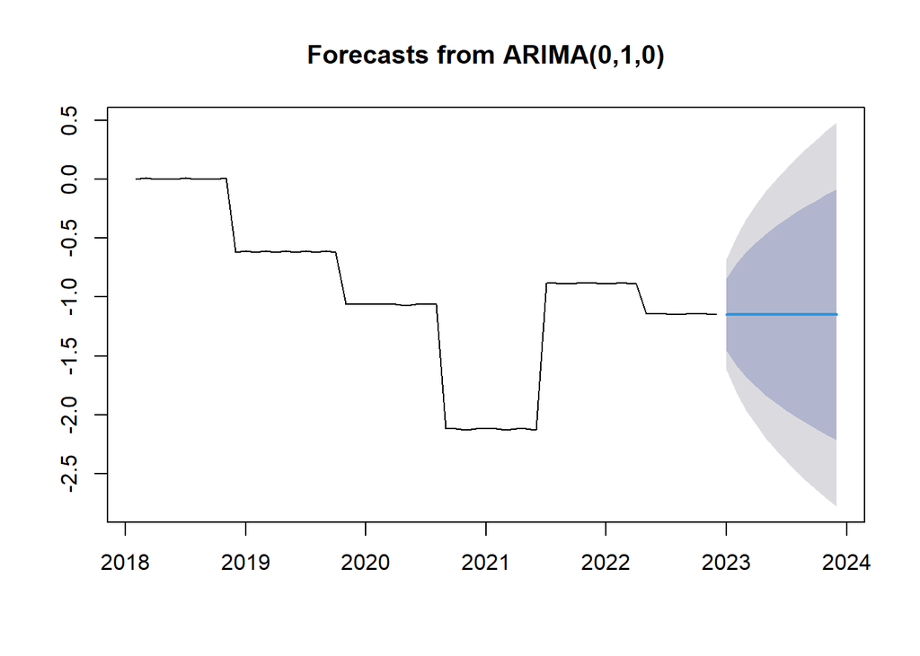

```
## [1] "Veamos mas en detalle la prediccion de los valores"
```

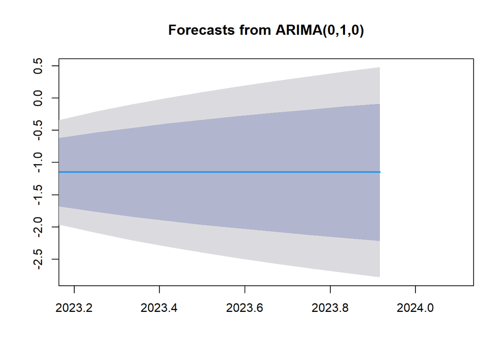

```
## [1] "Valores de la prediccion:"
```

```
##        Jan   Feb   Mar   Apr   May   Jun   Jul   Aug   Sep   Oct   Nov   Dec
## 2023 -1.15 -1.15 -1.15 -1.15 -1.15 -1.15 -1.15 -1.15 -1.15 -1.15 -1.15 -1.15
```

# **6. Modelos Logarítmicos, Prophet y otros**

## **6.1 Transformación Logarítmica**

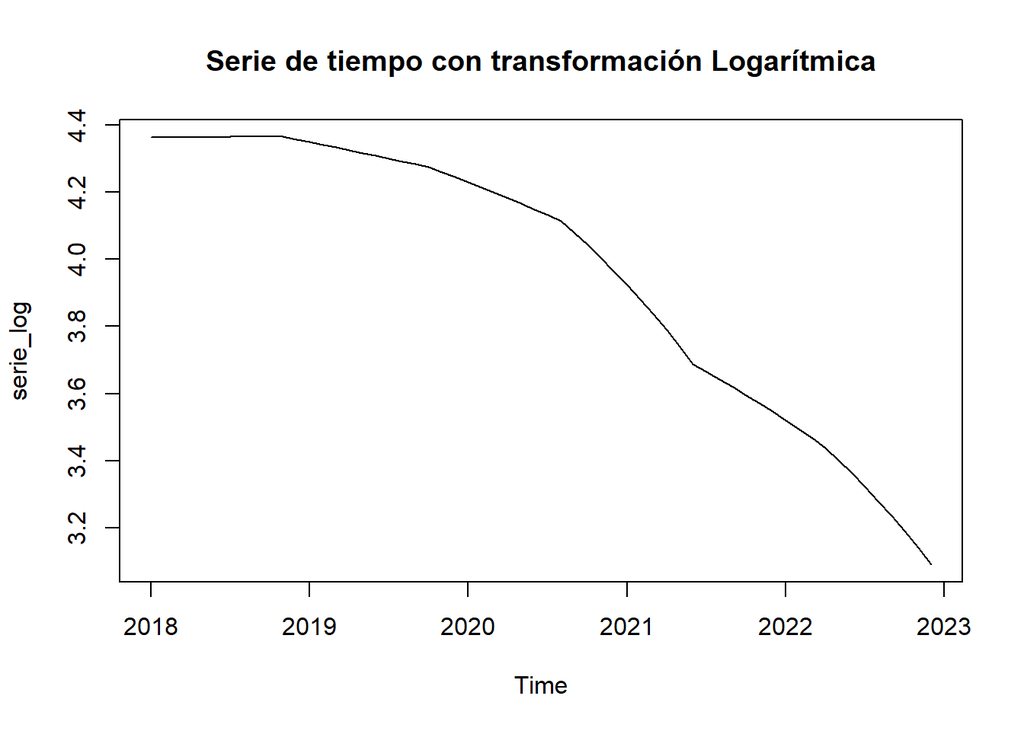

```r
# Aplicar la transformación logarítmica
serie_log <- log(indice.ts)

# Graficar la serie transformada
plot(serie_log, main = "Serie de tiempo con transformación Logarítmica")
```

## **6.2 Transformación con raíz cuadrada**

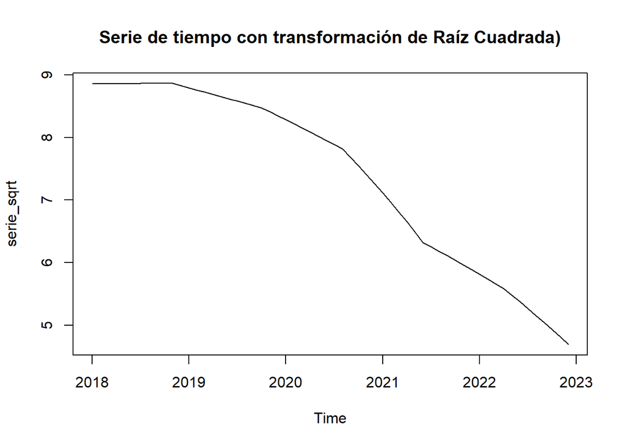

```r
# Aplicar la transformación de raíz cuadrada
serie_sqrt <- sqrt(indice.ts)

# Graficar la serie transformada
plot(serie_sqrt, main = "Serie de tiempo con transformación de Raíz Cuadrada)")
```

## **6.3 Modelo estacionario: Enfoque de regresión lineal clásico**

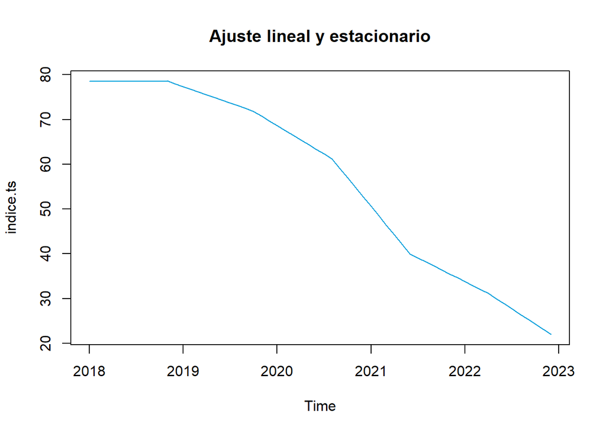

```r
# Crear una variable de tiempo numérica
time <- 1:length(indice.ts)

# Ajustar un modelo lineal y estacionario
lm_model <- lm(indice.ts ~ time)

# Obtener los coeficientes del modelo
coef_lm <- coef(lm_model)

# Graficar la serie de tiempo y el modelo ajustado
plot(indice.ts, type = "l", col = "#00a0dc", main = "Ajuste lineal y estacionario")
lines(fitted(lm_model), col = "red")
```

## **6.4 Algoritmo Facebook´s Prophet**

```r
library(prophet)
```

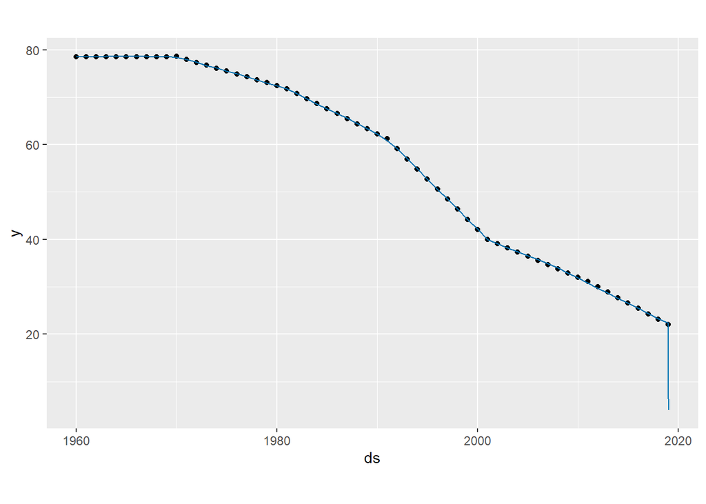

```r
# Crear un dataframe con la serie de tiempo
df <- data.frame(ds = data1$fecha,
                 y = data1$Primarios)

# Ajustar el modelo Prophet
prophet_model <- prophet(df, weekly.seasonality = TRUE, daily.seasonality = TRUE)

# Realizar un pronóstico para los próximos 12 meses
future <- make_future_dataframe(prophet_model, periods = 12)
forecast <- predict(prophet_model, future)

# Graficar el pronóstico
plot(prophet_model, forecast)
```

# **7. Modelo con Redes Neuronales**

## **7.1 Creacion de la TS normalizada**

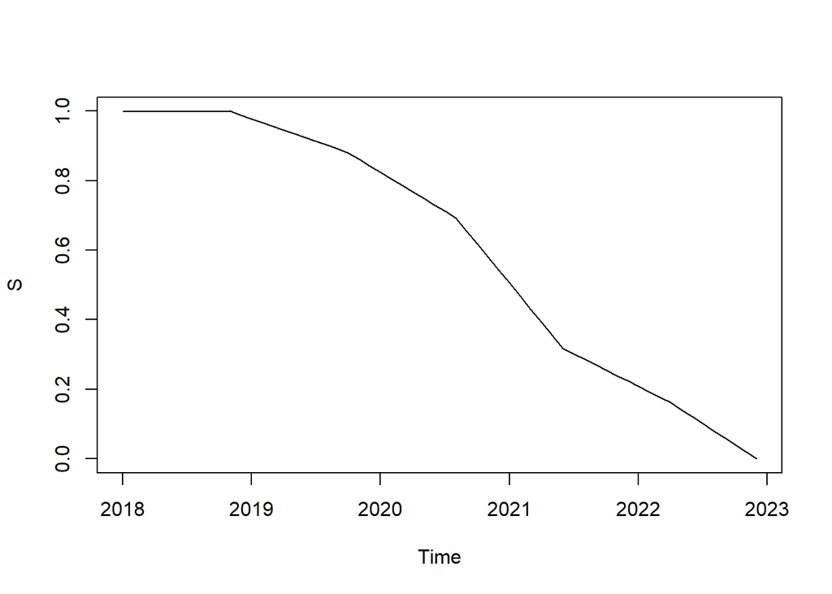

```r
Z <- as.ts(indice.ts,F)
S <- (Z-min(Z))/(max(Z)-min(Z))
plot(S)
```

## **7.2 División de la serie**

```r
lineas_totales <-length(S)
t_train <- round(lineas_totales*0.75, digits=0)
l_train <- 0:(t_train-1)
t_test <- (t_train):lineas_totales
t_test
```

```
##  [1] 45 46 47 48 49 50 51 52 53 54 55 56 57 58 59 60
```

## **7.3 Creación de Nodos**

```r
library(forecast)
library(timsac)
library(ggplot2)
library(changepoint)
library(RSNNS)
library(quantmod)
y <- as.zoo(S)
x1 <- Lag(y, k = 1)
x2 <- Lag(y, k = 2)
x3 <- Lag(y, k = 3)
x4 <- Lag(y, k = 4)
x5 <- Lag(y, k = 5)
x6 <- Lag(y, k = 6)
x7 <- Lag(y, k = 7)
x8 <- Lag(y, k = 8)
x9 <- Lag(y, k = 9)
x10 <- Lag(y, k = 10)
x11 <- Lag(y, k = 11)
x12 <- Lag(y, k = 12)
slogN <- cbind(y,x1,x2,x3,x4,x5,x6,x7,x8,x9,x10,x11,x12)
# Elimenemos los valores desplazados
slogN <- slogN[-(1:12),]
```

```r
inputs <- slogN[,2:13]
outputs <- slogN[,1]
```

## **7.4 Entrenamiento del modelo Elman**

```r
set.seed(42)
fit <- fit<-elman(inputs[t_train],outputs[t_train],size=c(110,5),learnFuncParams=c(0.1),maxit=100000)
```

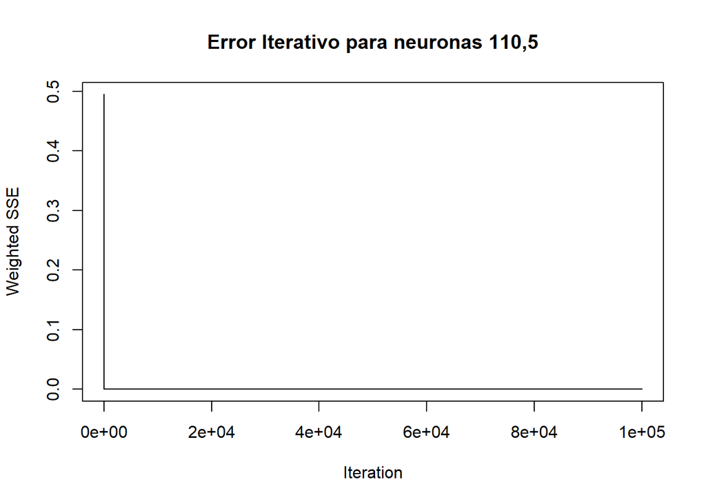

```r
plotIterativeError(fit, main = "Error Iterativo para neuronas 110,5")
```

**Predicción de la serie**

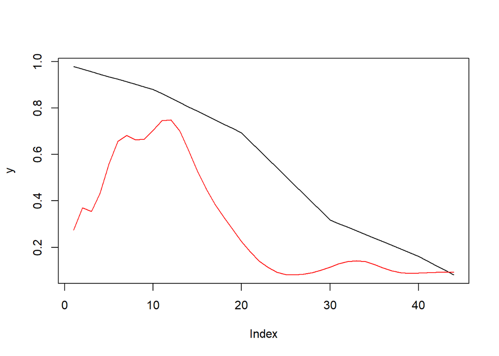

```r
y <- as.vector(outputs[-t_test])
plot(y,type="l")
pred <- predict(fit, inputs[-t_test])
lines(pred,col = "red")
```

```r
predictions <- predict(fit,inputs[-t_train])
```

```r
mod_elman <- predictions*(max(Z)-min(Z))+min(Z)
mod_elman
```

```
##                [,1]
## ene. 2019  29.92328
## feb. 2019  33.18616
## mar. 2019  38.49548
## abr. 2019  41.47521
## may. 2019  44.92517
## jun. 2019  44.07209
## jul. 2019  38.60164
## ago. 2019  33.37975
## sept. 2019 30.55554
## oct. 2019  29.62644
## nov. 2019  29.47000
## dic. 2019  29.97105
## ene. 2020  30.94344
## feb. 2020  32.02778
## mar. 2020  33.20363
## abr. 2020  34.21649
## may. 2020  34.96214
## jun. 2020  35.36913
## jul. 2020  35.38507
## ago. 2020  35.01831
## sept. 2020 34.47769
## oct. 2020  33.66833
## nov. 2020  33.16961
## dic. 2020  32.63108
## ene. 2021  32.35805
## feb. 2021  32.07491
## mar. 2021  31.88784
## abr. 2021  31.83814
## may. 2021  31.89880
## jun. 2021  31.93684
## jul. 2021  31.96969
## ago. 2021  31.71680
## sept. 2021 31.00712
## oct. 2021  30.11880
## nov. 2021  28.96496
## dic. 2021  28.01402
## ene. 2022  27.40439
## feb. 2022  27.09709
## mar. 2022  27.03475
## abr. 2022  27.13178
## may. 2022  27.18187
## jun. 2022  27.22078
## jul. 2022  27.25179
## ago. 2022  27.16675
## oct. 2022  27.09763
## nov. 2022  26.87958
## dic. 2022  26.70643
```

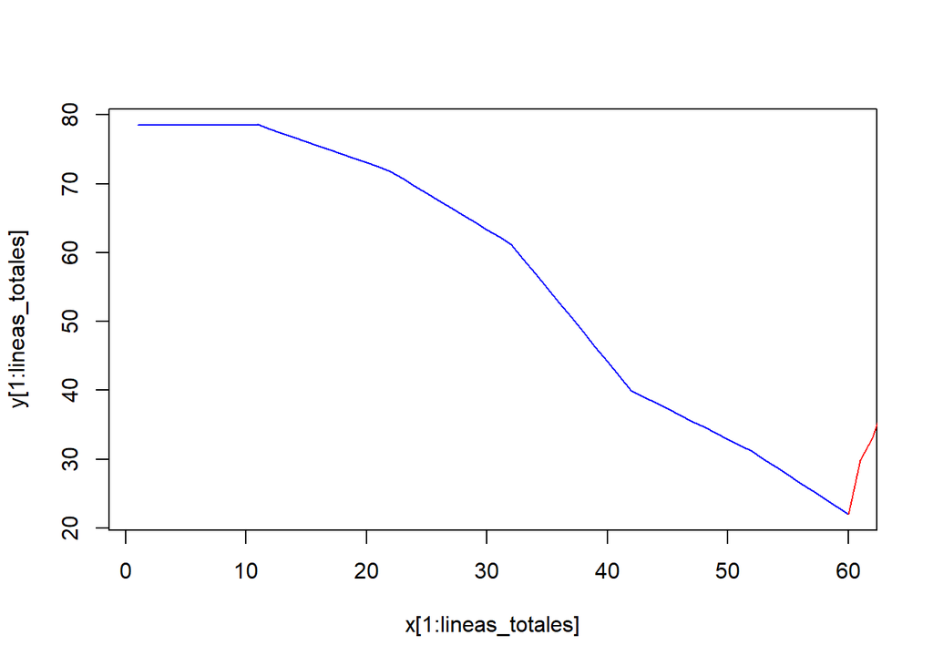

```r
x <- 1:(lineas_totales+length(mod_elman))
y <- c(as.vector(Z),mod_elman)
plot(x[1:lineas_totales], y[1:lineas_totales],col = "blue", type="l")
lines( x[(lineas_totales):length(x)], y[(lineas_totales):length(x)], col="red")
```

## **7.5 Modelo Jordan**

```r
fit<-jordan(inputs[t_train],
    outputs[t_train],
    size=12,
    learnFuncParams=c(0.01),
    maxit=100000)
```

**Error Iterativo**

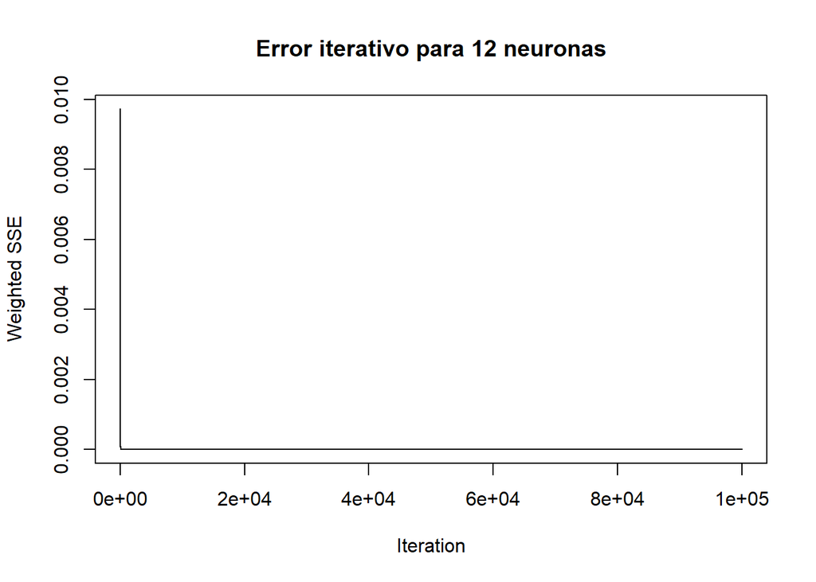

```r
plotIterativeError(fit, main = "Error iterativo para 12 neuronas")
```

**Comportamiento del error**

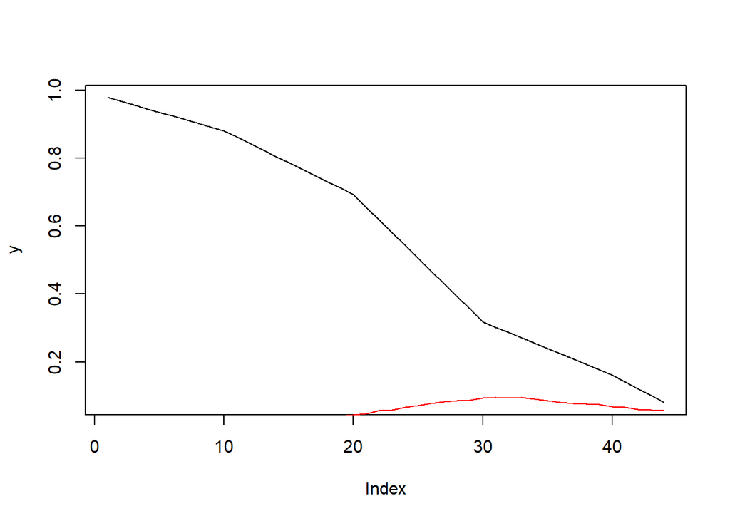

```r
y <- as.vector(outputs[-t_test])
plot(y,type="l")
pred <- predict(fit, inputs[-t_test])
lines(pred,col = "red")
```

**Predicción**

```r
predictions <- predict(fit,inputs[-t_train])
mod_jordan <- predictions*(max(Z)-min(Z))+min(Z)
mod_jordan
```

```
##                [,1]
## ene. 2019  21.94306
## feb. 2019  22.01998
## mar. 2019  22.20489
## abr. 2019  22.29028
## may. 2019  22.43564
## jun. 2019  22.51022
## jul. 2019  22.55644
## ago. 2019  22.60850
## sept. 2019 22.80172
## oct. 2019  22.88160
## nov. 2019  23.05863
## dic. 2019  23.27799
## ene. 2020  23.37040
## feb. 2020  23.56746
## mar. 2020  23.72499
## abr. 2020  23.90947
## may. 2020  24.05831
## jun. 2020  24.17315
## jul. 2020  24.29871
## ago. 2020  24.51400
## sept. 2020 24.65593
## oct. 2020  25.19556
## nov. 2020  25.32773
## dic. 2020  25.74136
## ene. 2021  26.03865
## feb. 2021  26.40576
## mar. 2021  26.65896
## abr. 2021  26.82009
## may. 2021  26.96379
## jun. 2021  27.30189
## jul. 2021  27.44004
## ago. 2021  27.30927
## sept. 2021 27.39816
## oct. 2021  27.10753
## nov. 2021  26.89543
## dic. 2021  26.61360
## ene. 2022  26.40789
## feb. 2022  26.30367
## mar. 2022  26.18993
## abr. 2022  25.85599
## may. 2022  25.73137
## jun. 2022  25.44073
## jul. 2022  25.31953
## ago. 2022  25.26933
## oct. 2022  25.09262
## nov. 2022  24.97076
## dic. 2022  24.81292
```

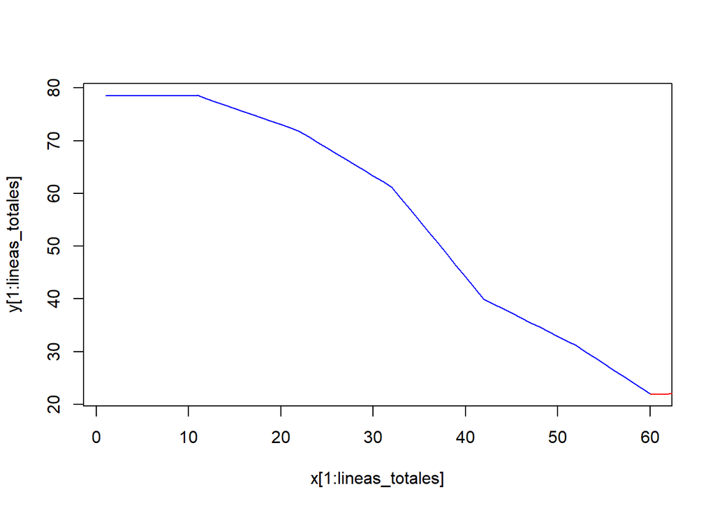

```r
x <- 1:(lineas_totales+length(mod_jordan))
y <- c(as.vector(Z),mod_jordan)
plot(x[1:lineas_totales], y[1:lineas_totales],col = "blue", type="l")
lines( x[(lineas_totales):length(x)], y[(lineas_totales):length(x)], col="red")
```

# **8. Referencias Bibliográficas**